# Plot GAM(M)s reference and difference smooths

Stefano Coretta

2017-10-31

Reference and difference smooths of factor predictos from a `gam` model can be plotted with `plot_gamsd()`. To illustrate how to use `plot_gamsd()`, let’s first prepare some dummy data with a factor variable and run `gam()` on this data. The `gam` model includes a reference smooth `s(x2)`, a by-factor difference smooth `s(x2, by = fac)`, and a smooth `s(x0)`.

```r
set.seed(10)
data <- gamSim(4)
```

```
## Factor `by' variable example
```

```r
model <- gam(
    y ~
        fac +
        s(x2) +
        s(x2, by = fac) +
        s(x0),
    data = data
)
```

We can now plot the estimated smooths for the two levels of `fac`, and the difference smooth. It is only possible to compare two levels at once, so here we plot `1` and `2`. Portions of the estimated smooths that are significantly different are indicated by a shaded red area both in the estimated smooths panel (top) and the difference smooth panel (bottom). Significance is based on the difference smooth: at any point, if the confidence interval of the difference smooth does not include 0, the difference between the estimated smooths is significant.

```
## Summary:
##  * fac : factor; set to the value(s): 1, 2.
##  * x2 : numeric predictor; with 100 values ranging from 0.001344 to 0.999801.
##  * x0 : numeric predictor; set to the value(s): 0.500503229675815.
```

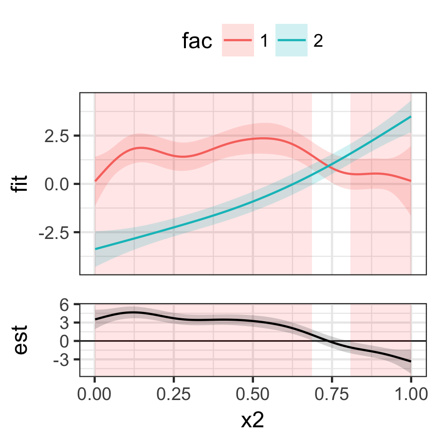

```r
plot_gamsd(
    model = model,
    view = "x2",
    comparison = list(fac = c("1", "2"))
)
```

Here we compare `1` with `3`, and we plot in black and white (gray scale).

```
## Summary:
##  * fac : factor; set to the value(s): 1, 3.
##  * x2 : numeric predictor; with 100 values ranging from 0.001344 to 0.999801.
##  * x0 : numeric predictor; set to the value(s): 0.500503229675815.
```

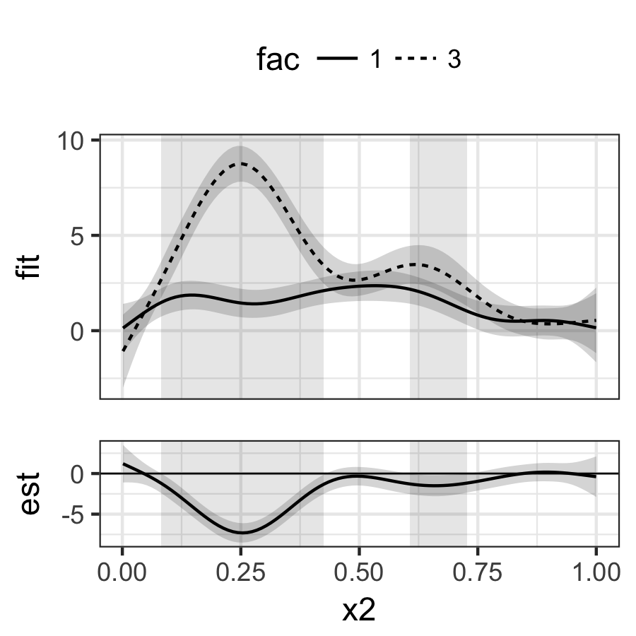

```r
plot_gamsd(
    model = model,
    view = "x2",
    comparison = list(fac = c("1", "3")),
    bw = TRUE
)
```